# Визуализация. Игры.

Установим и подгрузим пакеты.

```r
# install.packages('tidyr')
# install.packages('dplyr')
# install.packages('ggplot2')
# install.packages('readr')
library(tidyr)
library(dplyr)
library(ggplot2)
library(readr)
```

А теперь подгрузим данные.

```r
df <- read_csv('data/video_games_sales.csv')
glimpse(df)
```

```
## Rows: 16,719
## Columns: 16
## $ Name            <chr> "Wii Sports", "Super Mario Bros.", "Mario Kart Wii", …
## $ Platform        <chr> "Wii", "NES", "Wii", "Wii", "GB", "GB", "DS", "Wii", …
## $ Year_of_Release <chr> "2006", "1985", "2008", "2009", "1996", "1989", "2006…
## $ Genre           <chr> "Sports", "Platform", "Racing", "Sports", "Role-Playi…
## $ Publisher       <chr> "Nintendo", "Nintendo", "Nintendo", "Nintendo", "Nint…
## $ NA_Sales        <dbl> 41.36, 29.08, 15.68, 15.61, 11.27, 23.20, 11.28, 13.9…
## $ EU_Sales        <dbl> 28.96, 3.58, 12.76, 10.93, 8.89, 2.26, 9.14, 9.18, 6.…
## $ JP_Sales        <dbl> 3.77, 6.81, 3.79, 3.28, 10.22, 4.22, 6.50, 2.93, 4.70…
## $ Other_Sales     <dbl> 8.45, 0.77, 3.29, 2.95, 1.00, 0.58, 2.88, 2.84, 2.24,…
## $ Global_Sales    <dbl> 82.53, 40.24, 35.52, 32.77, 31.37, 30.26, 29.80, 28.9…
## $ Critic_Score    <dbl> 76, NA, 82, 80, NA, NA, 89, 58, 87, NA, NA, 91, NA, 8…
## $ Critic_Count    <dbl> 51, NA, 73, 73, NA, NA, 65, 41, 80, NA, NA, 64, NA, 6…
## $ User_Score      <chr> "8", NA, "8.3", "8", NA, NA, "8.5", "6.6", "8.4", NA,…
## $ User_Count      <dbl> 322, NA, 709, 192, NA, NA, 431, 129, 594, NA, NA, 464…
## $ Developer       <chr> "Nintendo", NA, "Nintendo", "Nintendo", NA, NA, "Nint…
## $ Rating          <chr> "E", NA, "E", "E", NA, NA, "E", "E", "E", NA, NA, "E"…
```

Видим, что некоторые колонки подгрузились не в том формате, что нам нужно. Колонки `Year_of_Release` и `User_Score` имеют формат *character* (текстовый), в то время как по смыслу должны иметь формат *double* (числовой). Изменим это:

```r
df$Year_of_Release <- as.numeric(df$Year_of_Release)
df$User_Score <- as.numeric(df$User_Score)
```

Теперь можем приступать к визуализации. Как обсуждалось на лекции, выбор графика зависит от типа признака, с которым вы работаете. Напомним, что все признаки делятся на **непрерывные** и **категориальные**. Далее рассмотрим примеры графиков для каждого из данных типов.

# Признаки по одному

## Непрерывный признак

#### Задача №1.

Посмотрите на динамику продаж игр в мире (`Global_Sales`) по годам.

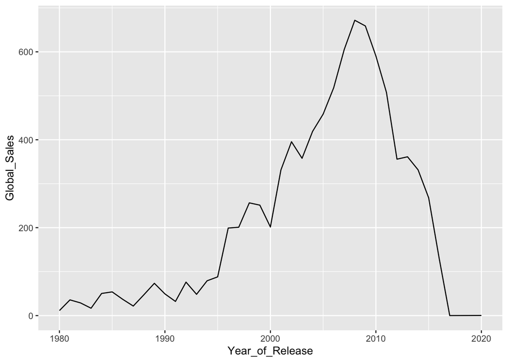

```r
df %>%
  group_by(Year_of_Release) %>%
  summarise(Global_Sales = sum(Global_Sales)) %>%
  ggplot(aes(x=Year_of_Release, y=Global_Sales)) + geom_line()
```

#### Задача №2.

Постройте один график, на котором будут отображаться сразу все показатели продаж (`NA_Sales`, `EU_Sales`, `JP_Sales`, `Other_Sales`, `Global_Sales`)

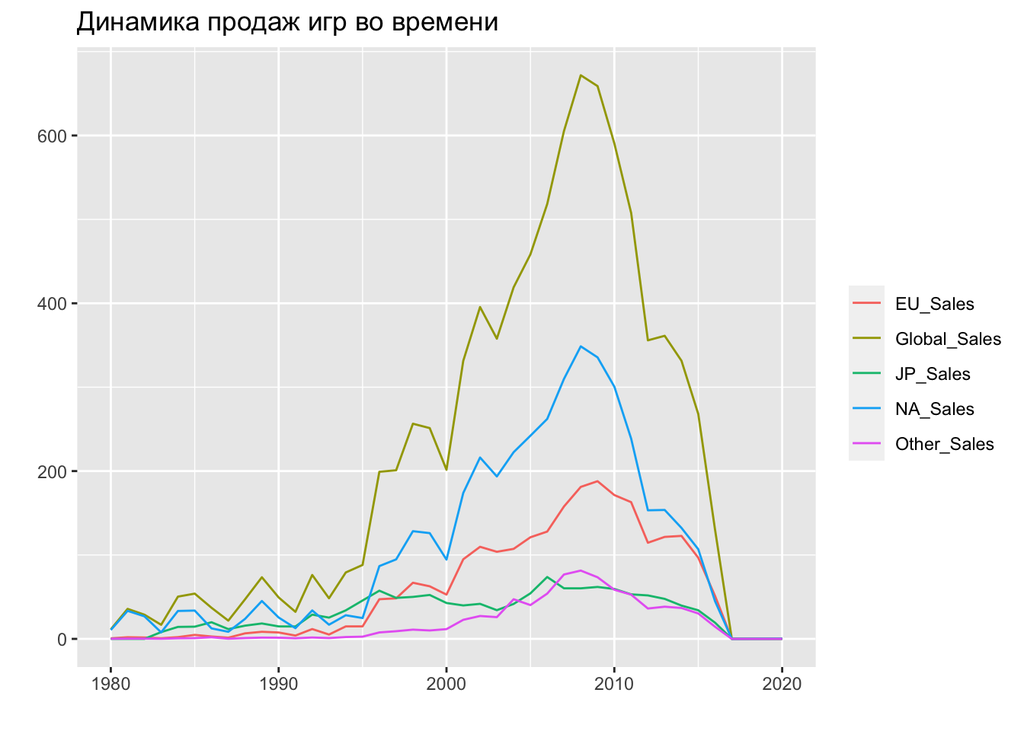

```r
df %>%
  group_by(Year_of_Release) %>%
  summarise(Global_Sales = sum(Global_Sales),
            NA_Sales = sum(NA_Sales),
            EU_Sales = sum(EU_Sales),
            JP_Sales = sum(JP_Sales),
            Other_Sales = sum(Other_Sales)) %>%
  gather(key='Sales_type', value='Sales', -Year_of_Release) %>%
  ggplot(aes(x=Year_of_Release, y=Sales, color=Sales_type)) + geom_line() +
  labs(title = 'Динамика продаж игр во времени',
       color = '',
       x = '',
       y = '')
```

Видим, что после 2000 года все резко начало меняться, давайте отметим эту линию на графике для наглядности:

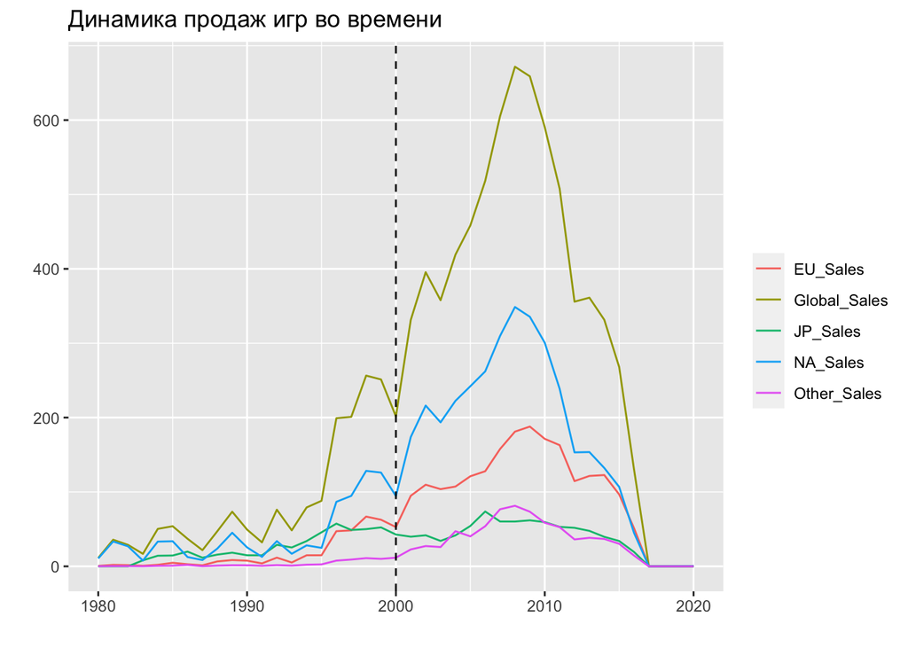

```r
df %>%
  group_by(Year_of_Release) %>%
  summarise(Global_Sales = sum(Global_Sales),
            NA_Sales = sum(NA_Sales),
            EU_Sales = sum(EU_Sales),
            JP_Sales = sum(JP_Sales),
            Other_Sales = sum(Other_Sales)) %>%
  gather(key='Sales_type', value='Sales', -Year_of_Release) %>%
  ggplot(aes(x=Year_of_Release, y=Sales, color=Sales_type)) + geom_line() +
  geom_vline(xintercept=2000, color='black', linetype=2) +
  labs(title = 'Динамика продаж игр во времени',
       color = '',
       x = '',
       y = '')
```

## Категориальный признак

#### Задача №3.

Сколько игр каждого жанра?

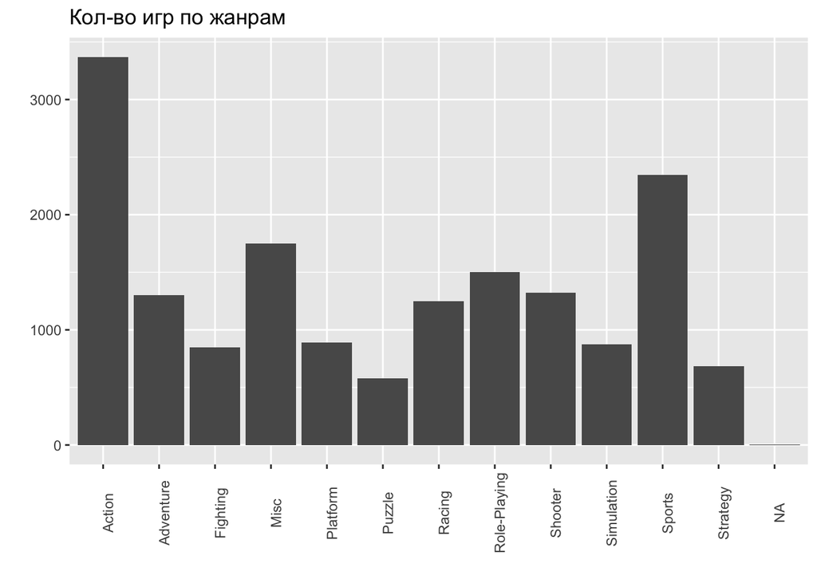

```r
df %>%
  group_by(Genre) %>%
  summarise(Number_of_Games = n()) %>%
  ggplot(aes(x=Genre, y=Number_of_Games)) + geom_col() +
  theme(axis.text.x = element_text(angle = 90)) +
  labs(x='', y='', title='Кол-во игр по жанрам')
```

# Зависимости признаков

## Непрерывный от непрерывного

#### Задача №4.

Посмотрите на зависимость продаж (`Global_Sales`) от оценки критиков (`Critic_Score`). Сделайте тоже самое, но отдельно в жанрах Sports, Action и Racing.

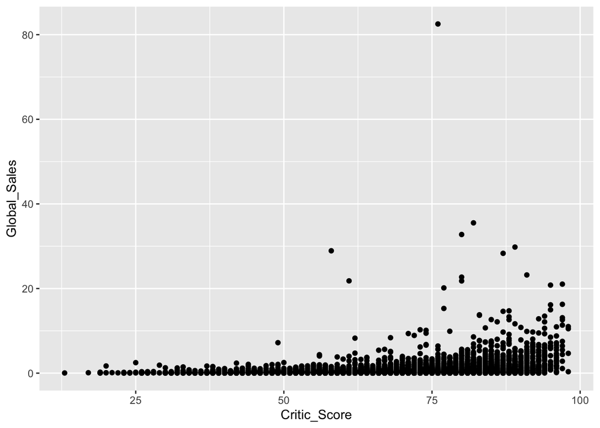

```r
df %>%
  ggplot(aes(x=Critic_Score, y=Global_Sales)) + geom_point()
```

Видим явный выброс, который чутка портит график. Построим без него.

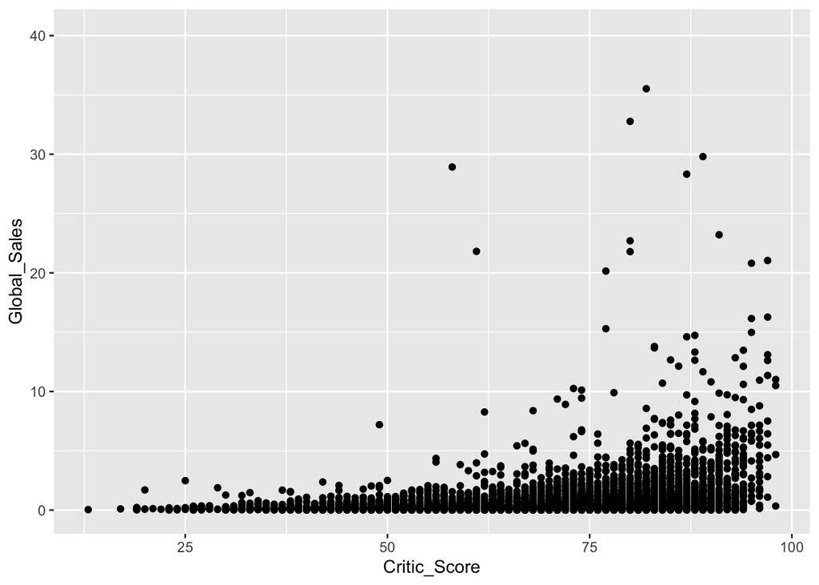

```r
df %>%
  filter(Global_Sales < 80) %>%
  ggplot(aes(x=Critic_Score, y=Global_Sales)) + geom_point()
```

Учитываем жанры:

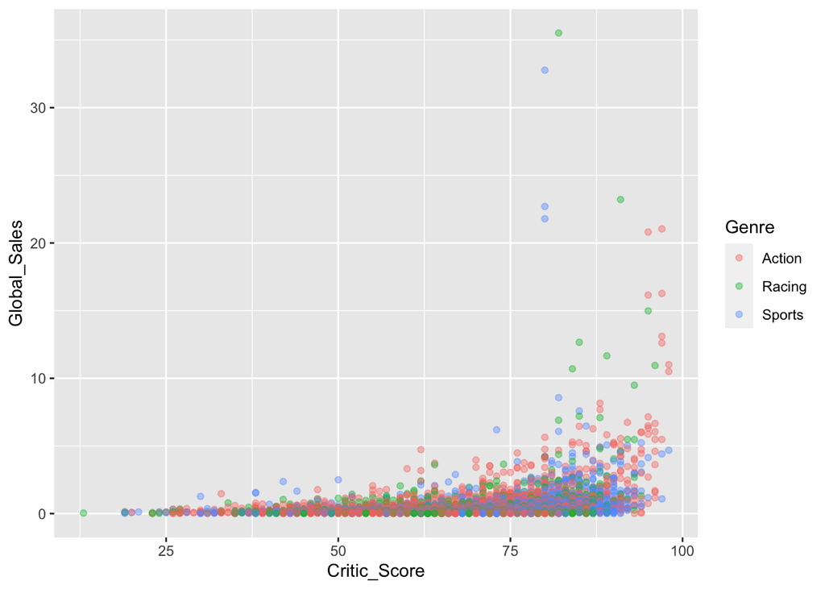

```r
df %>%
  filter(Genre %in% c('Sports', 'Action', 'Racing')) %>%
  filter(Global_Sales < 80) %>%
  ggplot(aes(x=Critic_Score, y=Global_Sales, color=Genre)) + geom_point(alpha=0.4)
```

## Непрерывный от категориального

#### Задача №5.

```r
# Отбираем крупнейшие платформы
df_platforms <- df %>%
        group_by(Platform) %>%
        summarise(Number_of_Games = n()) %>%
        arrange(desc(Number_of_Games)) %>%
        head(5)

platforms <- df_platforms$Platform

print(platforms)
```

```
## [1] "PS2"  "DS"   "PS3"  "Wii"  "X360"
```

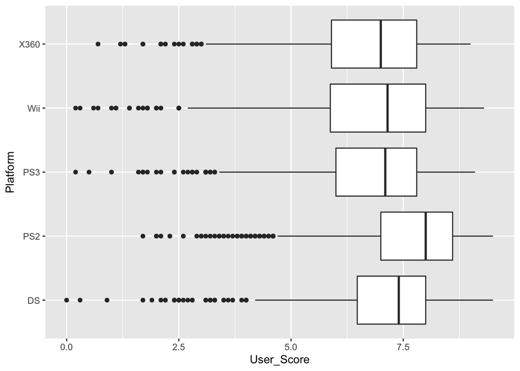

```r
# Строим график
df %>%
  filter(Platform %in% platforms) %>%
  ggplot(aes(x=User_Score, y=Platform)) + geom_boxplot()
```

Можем раскрасить :)

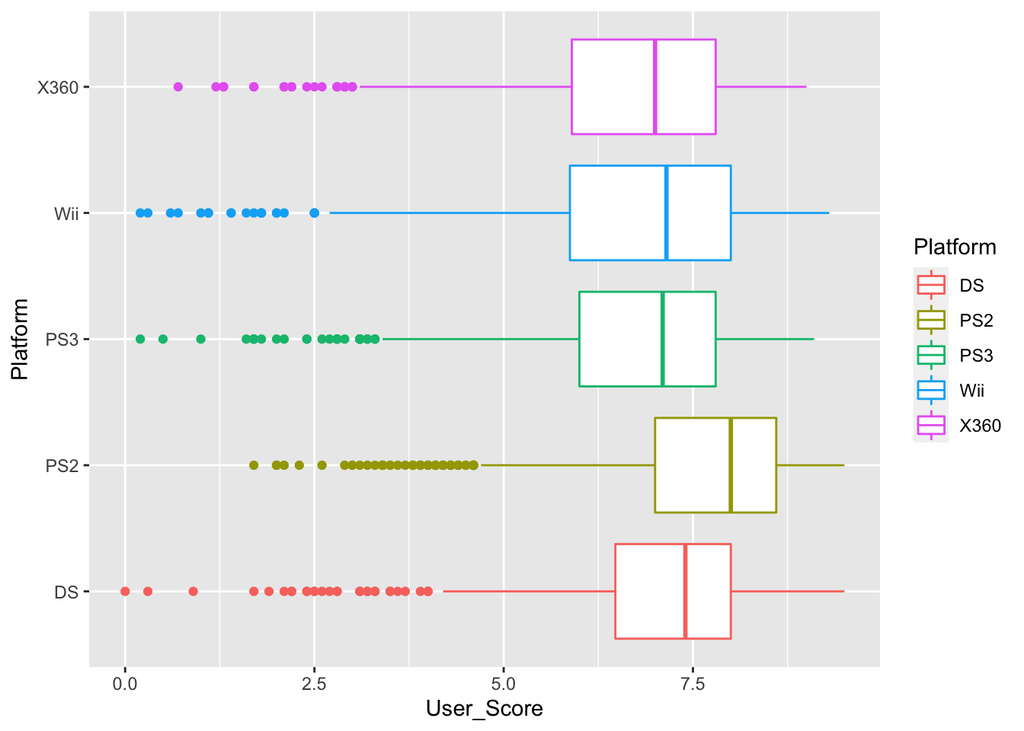

```r
df %>%
  filter(Platform %in% platforms) %>%
  ggplot(aes(x=User_Score, y=Platform, color=Platform)) + geom_boxplot()
```